# SHARP Multiomics Workshop: Exposome Challenge Data: Interactions

David Conti

2021-06-14 13:57:16

# SHARP MULTIOMICS WORKSHOP

## Data Descriptions for Interactions

# GxE Interaction ANALYSIS

## GxE: Overview

### The Question of interest:

- Is there effect heterogeneity for the association of **e3_asmokcigd_p_None** with the outcome **hs_bmi_c_cat** by germline genetics?

## GxE: Processing the Data

```r
load("~/Google Drive/My Drive/SHARP.MultiomicsWorkshop.USC.share/data/HELIX.MultiAssayExperiment.RData")

# not recommended way of storing genomewide data
variables <- c(covariate.Names, exposure.Name, "h_ethnicity_cauc", snp.Names)
# 1) select variables but keep in MultiAssayExperiment format; 2) intersectionColumns selects only individuals with complete data; 3) wideFormat returns as a DataFrame
d <- wideFormat(intersectColumns(helix_ma[variables, ,]), colDataCols=outcome.Name)
```

```
## harmonizing input:
##   removing 6732 sampleMap rows not in names(experiments)
```

```r
# Create  design matrix
X <- d[,grep("SNP", names(d))]
names(X) <- snp.Names
X <- as.matrix(X)

# Create the outcome variable
Y <- d[,outcome.Name] # outcome
if(outcome.Name=="hs_bmi_c_cat") { Y <- ifelse(as.numeric(Y)>=3, 1, 0)}

# Create the covariate design matrix
U <- d[,c(paste0("covariates_", covariate.Names[1:5]), paste0("proteome.cov_", covariate.Names[6:7]))]
names(U) <- covariate.Names
U[,c("h_cohort","e3_sex_None","h_edumc_None")] <- lapply(U[,c("h_cohort","e3_sex_None","h_edumc_None")], factor)
U[,c("h_mbmi_None", "h_age_None","ethn_PC1","ethn_PC2")] <- lapply(U[,c("h_mbmi_None", "h_age_None","ethn_PC1","ethn_PC2")], as.numeric)
U <- model.matrix(as.formula(paste("~-1+", paste(covariate.Names, collapse="+"))), data=U)
U = U[,-which(colnames(U) == "e3_sex_Nonemale")]



# Other variables for analysis
N <- nrow(d) # number of individuals in the analysis
Q <- ncol(U)  # number of covariates in the matrix U
P <- ncol(X)  # number of SNPs in the matrix X

# exposure variable
# E <- as.numeric(d[,grep(exposure.Name, names(d))])
E <- as.numeric(d[,grep(exposure.Name, names(d))])      #what David has in his rmd example
   E <- ifelse(E > 0,1,0)        #what I added since this is the E he used to simulate the gxe data
```

## GxE: Descriptive Statistics

- The genome includes a total of 1000 single nucleotide polymorphisms (SNPs):

### Plot of Genetic Ancestry as Estimated by Prinicpal Components (included in PreWorkshop Lab)

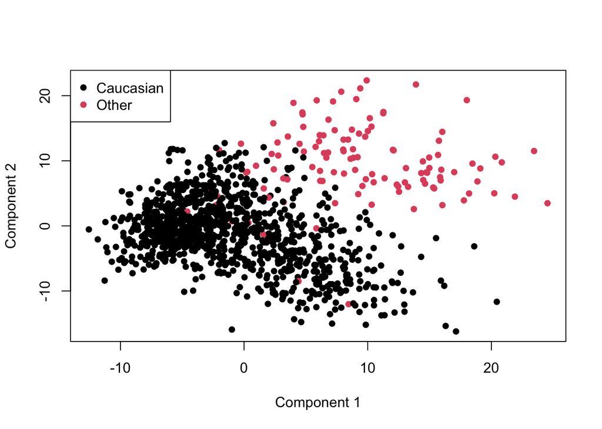

```r
plot(d$proteome.cov_ethn_PC1, d$proteome.cov_ethn_PC2, pch=16, col=ifelse(d$proteome.cov_h_ethnicity_cauc=="yes", 1, 2),
     xlab="Component 1", ylab="Component 2")
legend(x="topleft", legend=c("Caucasian", "Other"), col=c(1,2), pch=16)
```

### Correlation Matrix for Local Region of the Genome:

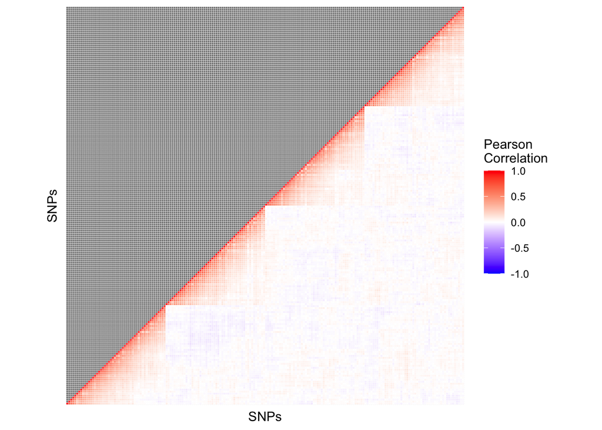

```r
cormat <- round(cor(X[,1:(P/5)], use="complete.obs"), 2)
cormat[lower.tri(cormat)]<- NA
melted_cormat <- melt(cormat)
ggplot(data = melted_cormat, aes(Var2, Var1, fill = value))+
  geom_tile(color = "white")+
  scale_fill_gradient2(low = "blue", high = "red", mid = "white",
                       midpoint = 0, limit = c(-1,1), space = "Lab",
                       name="Pearson\nCorrelation") +
  theme_minimal()+
  theme(axis.text.x = element_blank(), axis.text.y = element_blank())+
  labs(y= "SNPs", x = "SNPs")+
  coord_fixed()
```

## GxE: Statistical Approaches for Association Analysis

### GxE Univariate Regression

```r
if(GxE.univariate) {
  int.results <- t(sapply(1:ncol(X), FUN=function(p) {  # using index p faciliate write
    g <- X[,p]
    reg <- glm(Y~g*E+U, family=binomial)    # perform logistic regression
    s.reg <- summary(reg)                 # get the summary for the regression
    c.reg <- as.numeric(s.reg$coef["g:E",])             # select the coefficients
    # write.table(t(c(paste("SNP", p, sep="."), c.reg)), file="IntResultsGenome.txt", append=ifelse(p==1, F, T), quote=F, sep="\t", col.names=ifelse(p==1, T, F), row.names=F)
    return(c.reg)                         # to avoid potential memory issues only return coefficients if small number of exposures
  }, simplify=T))
  int.results <- data.frame(paste("E:SNP", 1:ncol(X), sep="."),int.results)
  names(int.results) <- c("E:SNP.Name","Estimate", "SD","Z.statistic", "P.value")
}
```

#### GxE Univariate results:

##### GxE Univariate Summary Table:

```r
if(GxE.univariate) { kable(int.results[int.results$P.value<0.05,], digits=3, align="c", row.names=FALSE, col.names=c("E:SNP","Estimate", "SD","Z statistic", "P value"))}
```

| E:SNP | Estimate | SD | Z statistic | P value |
| --- | --- | --- | --- | --- |
| E:SNP.51 | -0.669 | 0.294 | -2.277 | 0.023 |
| E:SNP.96 | -0.603 | 0.272 | -2.216 | 0.027 |
| E:SNP.100 | 0.513 | 0.220 | 2.331 | 0.020 |
| E:SNP.130 | -0.760 | 0.301 | -2.527 | 0.012 |
| E:SNP.132 | -0.619 | 0.304 | -2.039 | 0.041 |
| E:SNP.133 | -0.828 | 0.345 | -2.403 | 0.016 |
| E:SNP.174 | 1.238 | 0.370 | 3.348 | 0.001 |
| E:SNP.177 | 1.044 | 0.468 | 2.231 | 0.026 |
| E:SNP.180 | 0.773 | 0.312 | 2.478 | 0.013 |
| E:SNP.181 | 0.703 | 0.341 | 2.059 | 0.039 |
| E:SNP.183 | 0.639 | 0.247 | 2.586 | 0.010 |
| E:SNP.188 | 0.744 | 0.311 | 2.392 | 0.017 |
| E:SNP.227 | 0.965 | 0.382 | 2.522 | 0.012 |
| E:SNP.278 | 0.862 | 0.247 | 3.484 | 0.000 |
| E:SNP.363 | -0.723 | 0.333 | -2.169 | 0.030 |
| E:SNP.397 | -2.136 | 0.715 | -2.987 | 0.003 |
| E:SNP.462 | -0.814 | 0.352 | -2.317 | 0.021 |
| E:SNP.488 | -0.604 | 0.284 | -2.129 | 0.033 |
| E:SNP.489 | -0.791 | 0.363 | -2.176 | 0.030 |
| E:SNP.492 | -0.775 | 0.371 | -2.090 | 0.037 |
| E:SNP.502 | 0.886 | 0.246 | 3.609 | 0.000 |
| E:SNP.592 | -0.847 | 0.348 | -2.435 | 0.015 |
| E:SNP.603 | -1.193 | 0.446 | -2.673 | 0.008 |
| E:SNP.604 | -1.437 | 0.453 | -3.173 | 0.002 |
| E:SNP.606 | -0.595 | 0.290 | -2.056 | 0.040 |
| E:SNP.619 | -0.609 | 0.291 | -2.092 | 0.036 |
| E:SNP.620 | -1.433 | 0.597 | -2.402 | 0.016 |
| E:SNP.621 | -0.666 | 0.297 | -2.242 | 0.025 |
| E:SNP.625 | -0.725 | 0.303 | -2.391 | 0.017 |
| E:SNP.627 | -0.952 | 0.373 | -2.553 | 0.011 |
| E:SNP.732 | 0.575 | 0.282 | 2.039 | 0.041 |
| E:SNP.741 | 1.020 | 0.359 | 2.843 | 0.004 |
| E:SNP.743 | 0.828 | 0.301 | 2.752 | 0.006 |
| E:SNP.746 | 1.135 | 0.485 | 2.340 | 0.019 |
| E:SNP.877 | -0.855 | 0.314 | -2.725 | 0.006 |
| E:SNP.878 | -0.631 | 0.320 | -1.969 | 0.049 |
| E:SNP.879 | -0.712 | 0.336 | -2.120 | 0.034 |
| E:SNP.880 | -0.630 | 0.319 | -1.975 | 0.048 |
| E:SNP.900 | 0.946 | 0.233 | 4.057 | 0.000 |
| E:SNP.933 | 0.759 | 0.326 | 2.323 | 0.020 |
| E:SNP.936 | 0.897 | 0.374 | 2.397 | 0.017 |
| E:SNP.943 | 1.815 | 0.317 | 5.733 | 0.000 |
| E:SNP.957 | -0.708 | 0.315 | -2.247 | 0.025 |
| E:SNP.960 | -1.161 | 0.471 | -2.463 | 0.014 |
| E:SNP.967 | -0.615 | 0.291 | -2.111 | 0.035 |
| E:SNP.993 | 1.153 | 0.581 | 1.985 | 0.047 |

##### GxE Univariate Manhattan Plot:

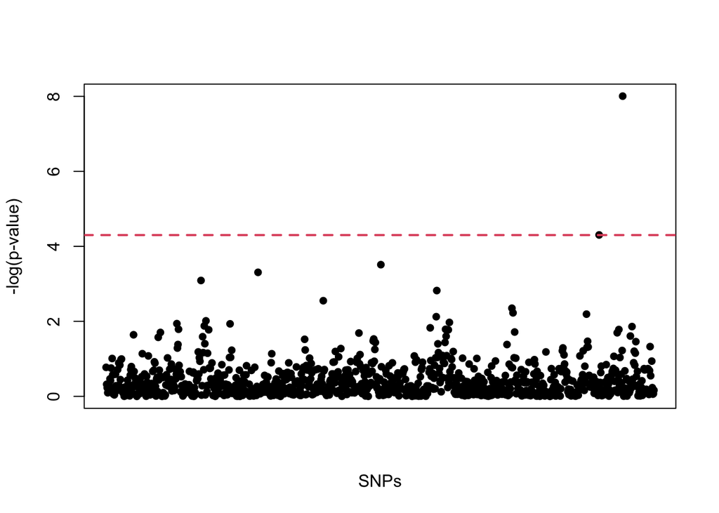

```r
neglog.pvalues <- -log10(int.results$P.value)
plot(1:nrow(int.results), neglog.pvalues,
     pch=16, xaxt="n", ylim=c(0, max(neglog.pvalues, 3)),
     ylab="-log(p-value)", xlab="SNPs")
abline(h=-log10(0.05/nrow(int.results)), lty=2, lwd=2, col=2)
```

##### GxE Univariate QQ-Plot:

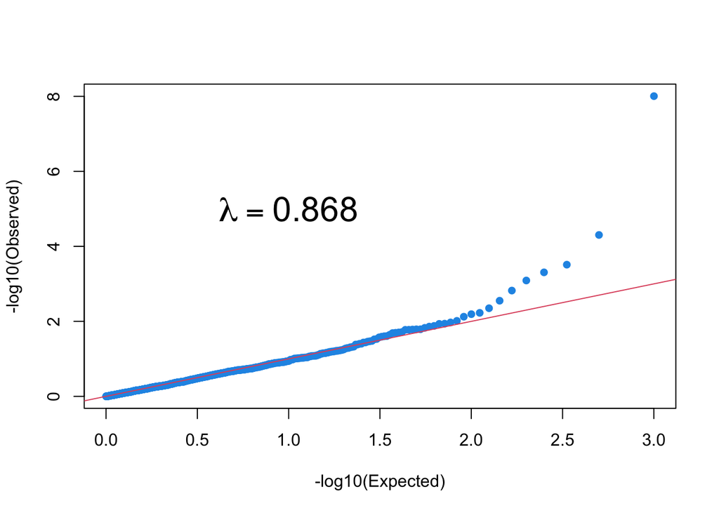

```r
pvalues <- int.results$P.value
r <- gcontrol2(pvalues, pch=16)
lambda <- round(r$lambda,3)
text(x=1, y=5, labels=bquote(lambda == .(lambda)), cex=2)
```

```r
options(warn=old.warn)
```

# GxEScanR

https://cran.r-project.org/web/packages/GxEScanR/index.html  
https://cran.r-project.org/web/packages/BinaryDosage/index.html

## Introduction

### BinaryDosage

Genotype imputation is an essential tool in genomics, enabling association testing with markers not directly genotyped, increasing statistical power, and facilitating data pooling between studies that employ different genotyping platforms. Two commonly used software packages for imputation are minimac and Impute2. Furthermore, services such as the Michigan Imputation Server have made genotype imputation much more accessible and streamlined.

While a number of software options are available for analyses of imputed data (e.g. PLINK, EPACTS), fewer are available for Genomewide Gene x Environment Interaction Scan (GWIS). Furthermore, data management tasks such as parsing, subsetting, and merging, while manageable in smaller studies, quickly become unwieldy and prohibitively slow with very large samples sizes. We aim to address these limitations by converting imputation outputs into a binary dosage file. The benefits of a binary format are two fold - decreased hard drive storage requirements (compared to a VCF file), and speed of parsing/analyses. The **BinaryDosage** package contains functions to convert VCF and Impute2 formatted files into binary dosage files, along with functions to merge samples.

### GxEScanR

**GxEScanR** is designed to efficiently run genome-wide association study (GWAS) and genome-wide by environmental interaction study (GWEIS) scans using imputed genotypes stored in the BinaryDosage format. The phenotype to be analyzed can either be a continuous or binary trait. The GWEIS scan performs multiple tests that can be used in two-step methods.

## Analysis

### Data preparation

BinaryDosage requires imputed genotype files as input. Generate VCF and INFO files (e.g. Minimac output)

```r
library(BinaryDosage)

# Create VCF file
vcf <- data.frame(t(X)) # transpose

# enter dummy values for required fields
vcf$chr <- "chr1"
vcf$pos <- seq(1,1000)
vcf$ID <- snp.Names
vcf$FORMAT <- "DS"
vcf[c('REF', 'ALT', 'QUAL', 'FILTER', 'INFO', 'Sample')] <- rep('.', nrow(vcf))

vcf <- vcf[, c('chr', 'pos', 'ID', 'REF', 'ALT', 'QUAL', 'FILTER', 'INFO', 'FORMAT')]
colnames(vcf) <- c('#CHROM', 'POS', 'ID', 'REF', 'ALT', 'QUAL', 'FILTER', 'INFO', 'FORMAT')
vcfout <- cbind(vcf, data.frame(t(X)))
write.table(vcfout, "./data/out.vcf", quote = F, row.names = F, col.names = T, sep = "\t")


# Create INFO file
info <- vcf[, c('ID', 'REF', 'ALT')]
info[c('AAF', 'MAF', 'AvgCall', 'Rsq')] <- rep(0.9, nrow(vcf))
info$Genotyped = "imputed"
info[c('LooRsq', 'EmpR', 'EmpRsq', 'Dose0', 'Dose1')] = "-"
info <- info[, c('ID', 'REF', 'ALT', 'AAF', 'MAF', 'AvgCall', 'Rsq', 'Genotyped', 'LooRsq', 'EmpR', 'EmpRsq', 'Dose0', 'Dose1')]
colnames(info) <- c('SNP', 'REF(0)', 'ALT(1)', 'ALT_Frq', 'MAF', 'AvgCall', 'Rsq', 'Genotyped', 'LooRsq', 'EmpR', 'EmpRsq', 'Dose0', 'Dose1')

write.table(info, "./data/out.info", quote = F, row.names = F, col.names = T, sep = "\t")

# output BinaryDosage file
BinaryDosage::vcftobd(vcffiles = c("./data/out.vcf", './data/out.info'), gz = FALSE, bdfiles = "./data/out.bdose")
```

## Run GxEScanR

Requires external covariate file - ID, Outcome, C, E (interaction variable must be in last position)

```r
library(BinaryDosage)
library(GxEScanR)

# read BinaryDosage info
bdinfo <- BinaryDosage::getbdinfo("/Users/mak/Desktop/out.bdose")


# Create covariate file
covar <- data.frame(U)
covar$outcome = Y
covar$e3_asmokcigd_p_None = E
covar$ID = paste0("X", seq(1, 1122))

covar <- covar[, c("ID", "outcome", "h_mbmi_None", "e3_sex_Nonefemale", "h_age_None", "h_cohort2", "h_cohort3", "h_cohort4", "h_cohort5", "h_cohort6", "h_edumc_None2", "h_edumc_None3", "ethn_PC1", "ethn_PC2", "e3_asmokcigd_p_None")]
write.table(covar, "./data/covar.txt", row.names = F, quote = F, sep = '\t')

# Run GxEScanR
output <- GxEScanR::gweis(data = covar, bdinfo = bdinfo)
```

```
## [1] "1122 subjects have complete data"
```

```r
# create EDGE statistic (used in two-step method)
output$lrtedge = output$lrtdg + output$lrteg
```

## Q-Q plots

```r
# qq plot function

plot_qq <- function(data, statistic, df) {
  pvalues <- pchisq(data[, statistic], df = df, lower.tail = F)
  r <- gcontrol2(pvalues, pch=16)
  lambda <- round(r$lambda,3)
  text(x=1, y=5, labels=bquote(lambda == .(lambda)), cex=2)
}
```

### D|G

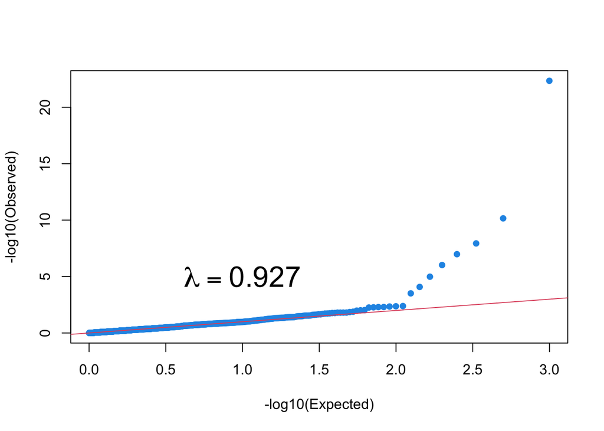

```r
plot_qq(output, 'lrtdg', 1)
```

### GxE

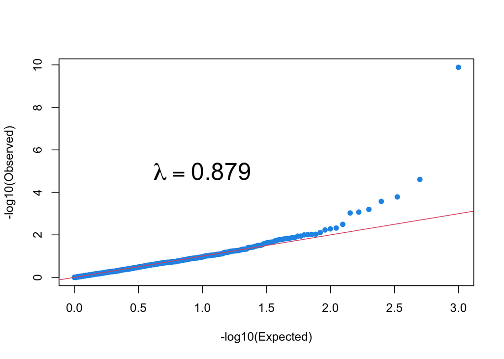

```r
plot_qq(output, 'lrtgxe', 1)
```

### 2DF

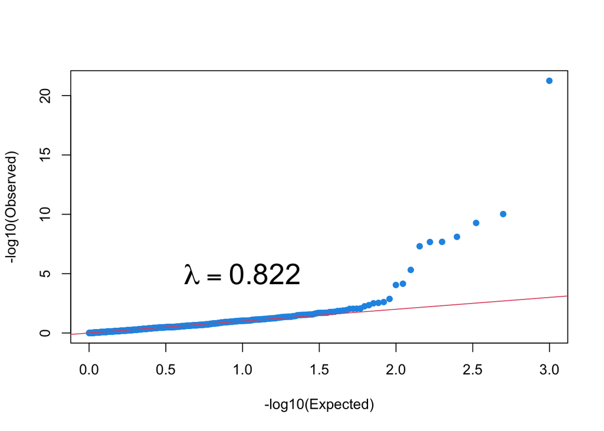

```r
plot_qq(output, 'lrt2df', 2)
```

### 3DF

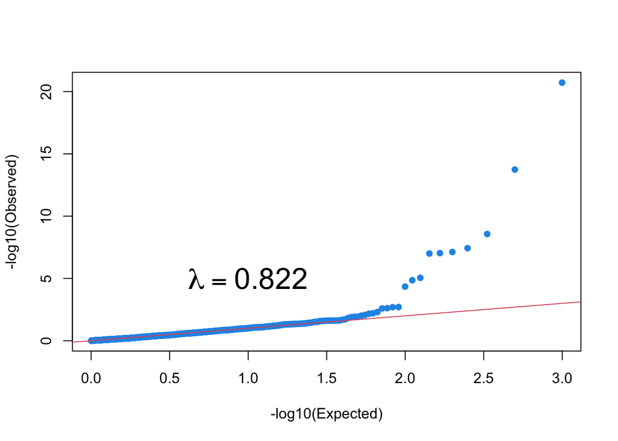

```r
plot_qq(output, 'lrt3df', 3)
```

## Manhattan plots

```r
# manhattan plot
plot_manhattan <- function(data, statistic, df) {
  neglog.pvalues <- -log10(pchisq(data[,statistic], lower.tail = F, df = df))
  plot(1:nrow(data), neglog.pvalues,
       pch=16, xaxt="n", ylim=c(0, max(neglog.pvalues, 3)),
       ylab="-log(p-value)", xlab="SNPs")
  abline(h=-log10(0.05/nrow(data)), lty=2, lwd=2, col=2)
}

# significant findings
sig_table <- function(data, statistic, df) {
  varname = paste0(statistic, "_pval")
  data[varname] <- pchisq(data[,statistic], lower.tail = F, df = df)
  out <- data[which(data[,varname] < (0.05 / nrow(data))), ]
  return(out[, c("snp", varname)])
}
```

### D|G

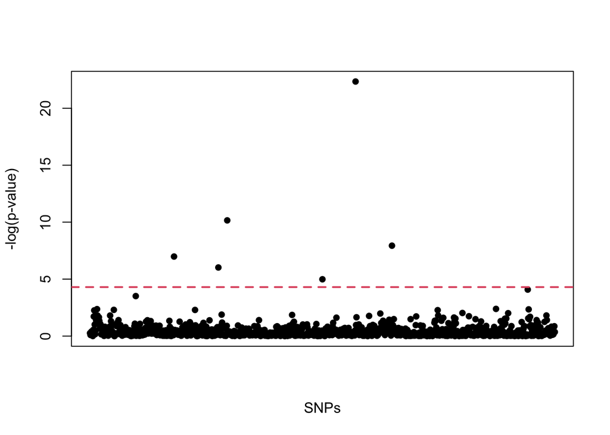

```r
plot_manhattan(output, 'lrtdg', 1)
```

### GxE

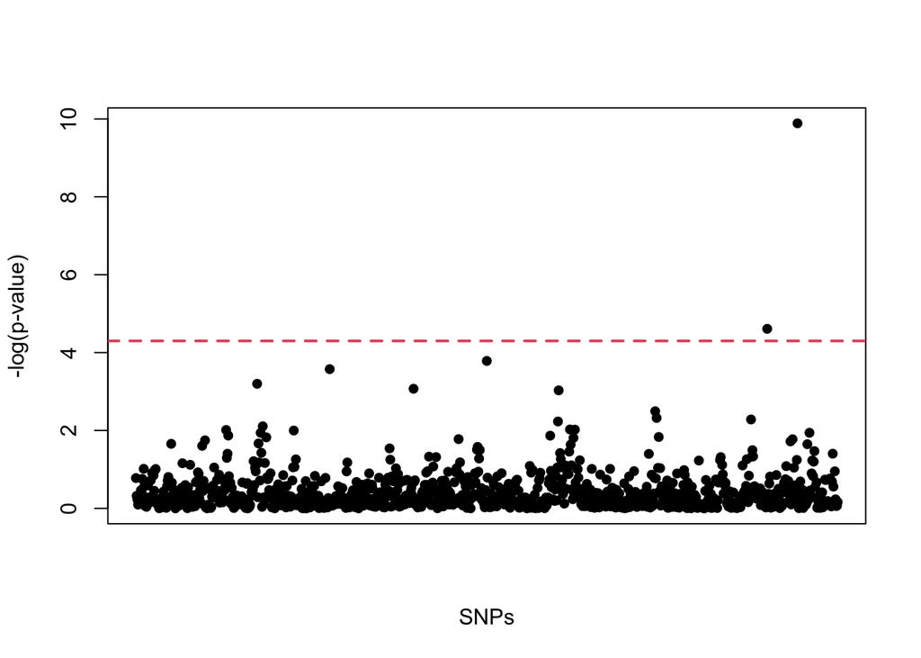

```r
plot_manhattan(output, 'lrtgxe', 1)
```

```r
kable(sig_table(output, 'lrtgxe', 1))
```

|  | snp | lrtgxe_pval |
| --- | --- | --- |
| 897 | SNP.900 | 2.45e-05 |
| 940 | SNP.943 | 0.00e+00 |

### 2DF

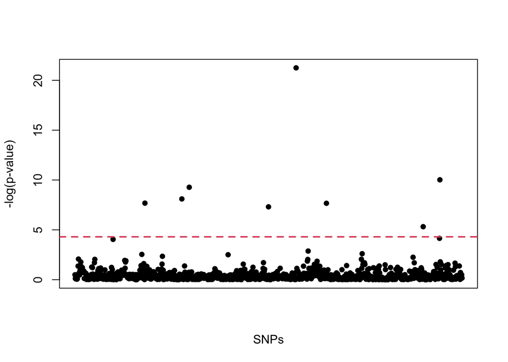

```r
plot_manhattan(output, 'lrt2df', 2)
```

### 3DF

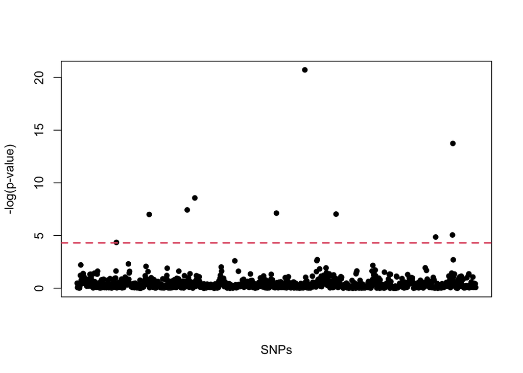

```r
plot_manhattan(output, 'lrt3df', 3)
```

## Two-step methods

```r
# twostep helper function
plot_twostep <- function(data, step1_statistic, step1_df, sizeBin0, alpha) {

  # create bins
  m = nrow(output)
  nbins = ceiling(log2(m/sizeBin0 + 1))
  sizeBin = c(sizeBin0 * 2^(0:(nbins-2)), m - sizeBin0 * (2^(nbins-1) - 1) )
  endpointsBin = cumsum(sizeBin)

  rk.pv <- c(1:m)
  grp <- ceiling(log(rk.pv/sizeBin0+1,base=2))
  rep_helper <- c(table(grp))
  alphaBin = alpha * 2 ^ -(1:nbins) / sizeBin
  alphaBin_dat <- rep(alphaBin, rep_helper)

  # create pvalues and bin variables
  data$step1p <- pchisq(data[, step1_statistic], df = step1_df, lower.tail = F)
  data$step2p <- pchisq(data[, 'lrtgxe'], df = 1, lower.tail = F)
  data                   <- data[order(-data[,step1_statistic]), ]   # sort by step1_statistic
  data$bin_number        <- as.numeric(grp)
  data$step2p_siglvl     <- as.numeric(alphaBin_dat)
  data$log_step2p_siglvl <- -log10(data$step2p_siglvl)
  data$log_step2p        <- -log10(data$step2p)

  significant_hits <- data[which(data$step2p < data$step2p_siglvl), ]

  # create plot
  # split data into lists (for each bin)
  data_plot <- split(data, f = list(data$bin_number))

  # mapinfo just to make sure SNPs are plotted evenly in each bin
  create_mapinfo <- function(x) {
    mapinfo <- seq(unique(x$bin_number) - 1 + 0.1, unique(x$bin_number) - 1 + 0.9, length.out = nrow(x))
    out <- cbind(x, mapinfo)
    return(out)
  }

  data_plot <- lapply(data_plot, create_mapinfo)
  logp_plot_limit = 12

  # PLOT
  binsToPlot = length(data_plot)
  color <- rep(c("#377EB8","#4DAF4A"),100)
  par(mar=c(6, 7, 6, 3))

  bin_to_plot = data_plot[[1]]
  plot(bin_to_plot$mapinfo, bin_to_plot$log_step2p,
       col = ifelse(bin_to_plot$snp %in% significant_hits[, 'snp'], '#E41A1C','#377EB8'),
       pch = ifelse(bin_to_plot$snp %in% significant_hits[, 'snp'], 19, 20),
       cex = ifelse(bin_to_plot$snp %in% significant_hits[, 'snp'], 1.3, 1.7),
       xlab="Bin number for step1 p value",
       ylab="-log10(step2 chiSqGxE p value)",
       xlim=c(0, binsToPlot),
       ylim=c(0, logp_plot_limit),
       axes=F,
       cex.main = 1.7,
       cex.axis = 1.7,
       cex.lab = 1.7,
       cex.sub = 1.7)
  lines(bin_to_plot$mapinfo, bin_to_plot$log_step2p_siglvl, col = "black", lwd=1)

  # remaining bins
  for(i in 2:binsToPlot) {
    bin_to_plot = data_plot[[i]]
    points(bin_to_plot$mapinfo, bin_to_plot$log_step2p,
           col = ifelse(bin_to_plot$snp %in% significant_hits$snp, '#E41A1C', color[i]),
           pch = ifelse(bin_to_plot$snp %in% significant_hits$snp, 19, 20),
           cex = ifelse(bin_to_plot$snp %in% significant_hits$snp, 1.3, 1.7),
           cex.main = 1.7,
           cex.axis = 1.7,
           cex.lab = 1.7,
           cex.sub = 1.7)
    lines(bin_to_plot$mapinfo, bin_to_plot$log_step2p_sig, col = "black",lwd = 1)
  }

  axis(1, at = c(-1.5, seq(0.5, binsToPlot-0.2, 1)), label = c(0, seq(1, binsToPlot, 1)), cex.axis = 1.7)
  axis(2, at = c(0:floor(logp_plot_limit)), label = c(0:logp_plot_limit), cex.axis=1.7)

}


# significant findings
# report SNP, step1, step2

sig_twostep <- function(data, step1_statistic, step1_df, sizeBin0, alpha) {

  # create bins
  m = nrow(output)
  nbins = ceiling(log2(m/sizeBin0 + 1))
  sizeBin = c(sizeBin0 * 2^(0:(nbins-2)), m - sizeBin0 * (2^(nbins-1) - 1) )
  endpointsBin = cumsum(sizeBin)

  rk.pv <- c(1:m)
  grp <- ceiling(log(rk.pv/sizeBin0+1,base=2))
  rep_helper <- c(table(grp))
  alphaBin = alpha * 2 ^ -(1:nbins) / sizeBin
  alphaBin_dat <- rep(alphaBin, rep_helper)

  # create pvalues and bin variables
  data$step1p <- pchisq(data[, step1_statistic], df = step1_df, lower.tail = F)
  data$step2p <- pchisq(data[, 'lrtgxe'], df = 1, lower.tail = F)
  data                   <- data[order(-data[,step1_statistic]), ]   # sort by step1_statistic
  data$bin_number        <- as.numeric(grp)
  data$step2p_siglvl     <- as.numeric(alphaBin_dat)
  data$log_step2p_siglvl <- -log10(data$step2p_siglvl)
  data$log_step2p        <- -log10(data$step2p)

  significant_hits <- data[which(data$step2p < data$step2p_siglvl), c("snp", "step1p", "step2p")]

  return(significant_hits)
}
```

### Twostep D|G

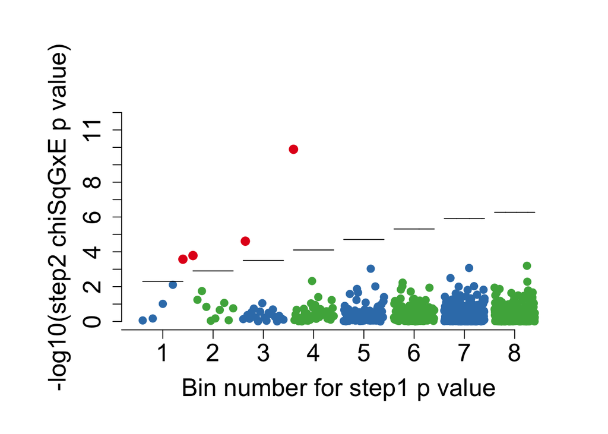

```r
plot_twostep(output, step1_statistic = 'lrtdg', step1_df = 1, sizeBin0 = 5, alpha = 0.05)
```

```r
kable(sig_twostep(output, step1_statistic = 'lrtdg', step1_df = 1, sizeBin0 = 5, alpha = 0.05)) %>% kable_styling()
```

|  | snp | step1p | step2p |
| --- | --- | --- | --- |
| 276 | SNP.278 | 0.0000010 | 0.0002661 |
| 499 | SNP.502 | 0.0000103 | 0.0001635 |
| 897 | SNP.900 | 0.0097750 | 0.0000245 |
| 940 | SNP.943 | 0.0278534 | 0.0000000 |

### Twostep E|G

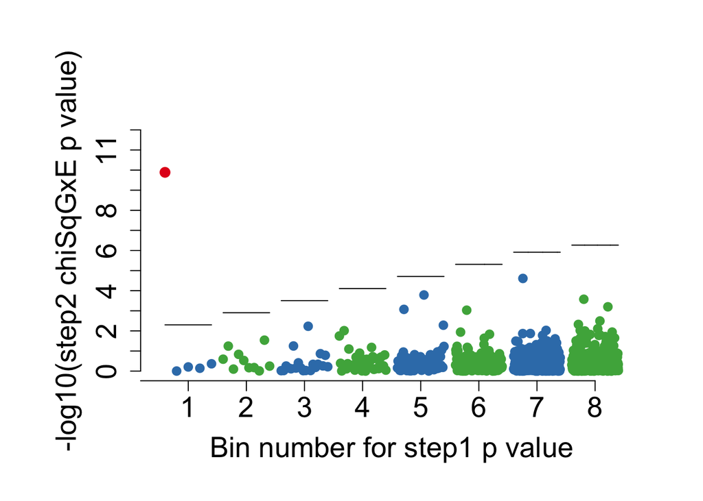

```r
plot_twostep(output, step1_statistic = 'lrteg', step1_df = 1, sizeBin0 = 5, alpha = 0.05)
```

```r
kable(sig_twostep(output, step1_statistic = 'lrteg', step1_df = 1, sizeBin0 = 5, alpha = 0.05)) %>% kable_styling()
```

|  | snp | step1p | step2p |
| --- | --- | --- | --- |
| 940 | SNP.943 | 4.8e-06 | 0 |

### Twostep EDGE

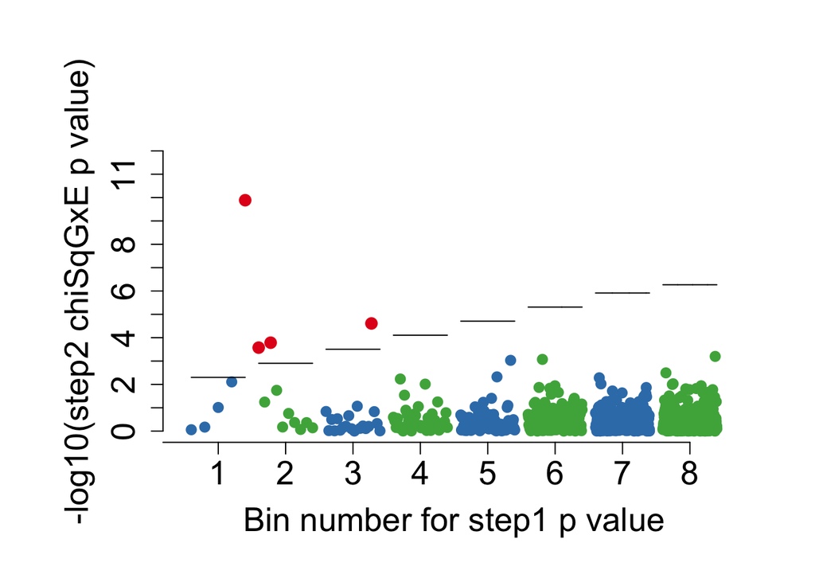

```r
plot_twostep(output, step1_statistic = 'lrtedge', step1_df = 2, sizeBin0 = 5, alpha = 0.05)
```

```r
kable(sig_twostep(output, step1_statistic = 'lrtedge', step1_df = 2, sizeBin0 = 5, alpha = 0.05)) %>% kable_styling()
```

|  | snp | step1p | step2p |
| --- | --- | --- | --- |
| 940 | SNP.943 | 0.0000026 | 0.0000000 |
| 276 | SNP.278 | 0.0000058 | 0.0002661 |
| 499 | SNP.502 | 0.0000187 | 0.0001635 |
| 897 | SNP.900 | 0.0246558 | 0.0000245 |